# Carmen

Opéra comique in vier Akten (1875)

Musik von Georges Bizet  
Text von Henri Meilhac und Ludovic Halévy nach Prosper Mérimée

[Tickets](https://staatsoper-berlin.eventim-inhouse.de/webshop/webticket/shop?language=de&event=18236)

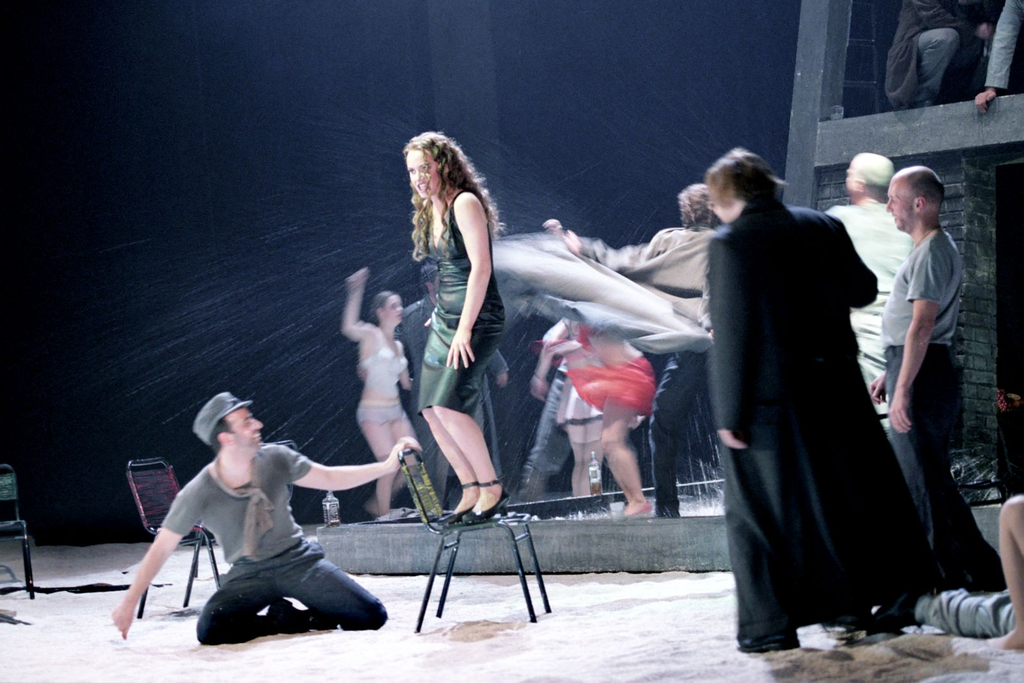

Eine tragisch endende Opéra comique, die das ewige Spiel von leidenschaftlicher Liebe und quälender Eifersucht auf die Bühne bringt, und deren zündende Musik das Publikum weltweit angesprochen hat und immer wieder neu anspricht, das ist Bizets Carmen. Wechselseitige Anziehungs- und Abstoßungskräfte wirken, mit letztlich fatalen Folgen – getragen und verantwortet von eigenwilligen, in Erinnerung bleibenden Charakteren.

Den Erfolg seiner im Frühjahr 1875 in Paris uraufgeführten Carmen konnte das Jahrhunderttalent Georges Bizet allenfalls ahnen, aber nicht mehr genießen. Als seine Oper zum 33. Mal aufgeführt wurde, starb er im Alter von erst 38 Jahren. Heute gehört Carmen zu den meistgespielten Stücken des Repertoires überhaupt, ein Ende des enthusiastischen Echos ist nicht in Sicht. Nicht wenige Musiknummern sind zu wahren „Hits“ geworden, das südliche Klangkolorit und die leuchtenden Orchesterfarben, die etwas sehr Sinnliches ausstrahlen, schaffen zusätzliche Reize. Raffiniert gemacht ist diese Musik, die so stimmig mit dem dramatischen Geschehen zusammentrifft, und dabei doch so eingängig, im guten Sinne „populär“. Jede der Figuren erhält ihr eigenes musikalisches Profil – lebensechte Menschen kommen auf die Bühne, in quasi-realistischer Art, was die Glaubwürdigkeit ihres Singens und Handelns unterstützt. Bizets Carmen ist eines der erklärten Meisterwerke der Opernliteratur.

Familienvorstellung Zum letzten Mal in dieser Spielzeit

Sonntag, 5. Januar 2025  
18.00 Uhr

[Staatsoper Unter den Linden](https://www.staatsoper-berlin.de/de/ihr-besuch/anfahrt/staatsoper-unter-den-linden.35/)

[Tickets](https://staatsoper-berlin.eventim-inhouse.de/webshop/webticket/shop?language=de&event=18236)

Dauer: ca. 3:20 h inklusive einer Pause nach dem 2. Akt

Sprache: In französischer Sprache mit deutschen und englischen Übertiteln

Altersempfehlung: ab 12 Jahren

## Besetzung

- Musikalische Leitung:

  [Valentin Uryupin](https://www.staatsoper-berlin.de/de/kuenstler/valentin-uryupin.3497/)
- Inszenierung:

  [Martin Kušej](https://www.staatsoper-berlin.de/de/kuenstler/martin-kusej.2347/)
- Szenische Einstudierung, Spielleitung:

  Katharina Lang
- Spielleitung:

  [Tabatha McFadyen](https://www.staatsoper-berlin.de/de/kuenstler/tabatha-mcfadyen.3591/)
- Bühne:

  [Jens Kilian](https://www.staatsoper-berlin.de/de/kuenstler/jens-kilian.1497/)
- Kostüme:

  [Heidi Hackl](https://www.staatsoper-berlin.de/de/kuenstler/heidi-hackl.2348/)
- Licht:

  [Reinhard Traub](https://www.staatsoper-berlin.de/de/kuenstler/reinhard-traub.1904/)
- Carmen:

  [Gaëlle Arquez](https://www.staatsoper-berlin.de/de/kuenstler/gaelle-arquez.3241/)
- Don José:

  [Ivan Gyngazov](https://www.staatsoper-berlin.de/de/kuenstler/ivan-gyngazov.3498/)
- Escamillo:

  [Łukasz Goliński](https://www.staatsoper-berlin.de/de/kuenstler/lukasz-golinski.2751/)
- Dancaïro:

  [Jaka Mihelač](https://www.staatsoper-berlin.de/de/kuenstler/jaka-mihelac.2236/)
- Remendado:

  [Andrés Moreno García](https://www.staatsoper-berlin.de/de/kuenstler/andres-moreno-garcia.1512/)
- Moralès:

  [Roman Trekel](https://www.staatsoper-berlin.de/de/kuenstler/roman-trekel.1129/)
- Zuniga:

  [Jan Martiník](https://www.staatsoper-berlin.de/de/kuenstler/jan-martinik.1086/)
- Micaëla:

  [Clara Nadeshdin](https://www.staatsoper-berlin.de/de/kuenstler/clara-nadeshdin.2855/)
- Mercédès:

  [Rebecka Wallroth](https://www.staatsoper-berlin.de/de/kuenstler/rebecka-wallroth.3275/)
- Frasquita:

  [Maria Kokareva](https://www.staatsoper-berlin.de/de/kuenstler/maria-kokareva.3270/)
- Lillas Pastia:

  [Sébastien Dutrieux](https://www.staatsoper-berlin.de/de/kuenstler/sebastien-dutrieux.3422/)
- - [Staatsopernchor](https://www.staatsoper-berlin.de/de/kuenstler/staatsopernchor.1020/),
  - [Kinderchor der Staatsoper](https://www.staatsoper-berlin.de/de/kuenstler/kinderchor-der-staatsoper.2748/),
  - [Staatskapelle Berlin](https://www.staatsoper-berlin.de/de/kuenstler/staatskapelle-berlin.1019/)